# RestoreDART initial results summary

BEM

September 2026

## Notes

- This document reports results **across objectives**: the cross-objective direction checks, then every table and figure compiled from all five objective x cover response combinations, then the interpretation. It does not contain the per-objective sections. Those - the pixel counts, the sparse treatment x ecoregion combinations, what each sample-size filter removed, the count histograms, and each objective’s own results and interpretation - are in `2_sample_size_checks.Rmd`, which is where the filtering and sample-size decisions are made and documented. The bulky per-ecoregion reference panels are in `2_raw_result_graphs.Rmd`.
- Nothing in this document computes what it displays, and nothing here sets a threshold. `2_results_setup.R` does both, for all three documents at once, so a threshold change takes effect everywhere and no two documents can report different numbers for the same quantity.
- Every compiled table below is therefore built on post-filter data, and on *unequally* filtered data, since the thresholds differ by objective. The filtering log is the first thing compiled for that reason: read it before comparing objectives to each other.
- The document runs in this order: terminology, the cross-objective direction checks, the compiled tables and figures, and last the hand-written interpretation - placed at the end so that it can refer back to evidence the reader has already passed.

## Terminology: raw sign versus management intent

“positive”/“negative” and “intended”/“unintended” are used here for two different things, and they are not interchangeable. “Positive effect” and “negative effect” always refer to the raw sign of the (differenced) RAP cover effect itself, independent of any objective - a positive effect means RAP cover went up, a negative effect means it went down. “Intended” and “unintended” always refer to that same raw sign *relative to the assigned objective’s management goal*: for a `decrease_*` objective, a negative effect is intended and a positive effect is unintended; for an `increase_*` objective, it’s the reverse. So a significant positive effect is a *good* (intended) result under `increase_pfg`, but a *bad* (unintended) result under `decrease_afg` - same raw sign, opposite management meaning. `get_intended_sign()`, `label_intended()` and `intended_dir_word()` (`helper_functions.R`) encode this mapping in one place so it’s applied consistently everywhere this distinction matters (e.g. `reduce_s0()`’s `sig_des`/`sig_und` columns, the “Intended”/“Unintended” columns of the summary table below, and the stacking order of the direction figures). Which of the two a given table or figure uses now follows a single rule: **within one objective’s section, intended; across objectives, raw sign.** The three `summarize_sig_effect()` figures in each section (by fine objective, by treatment, by ecoregion) report the *intended* effect, because every level on those axes shares that section’s management goal and a bar labelled “significant positive” invited reading a `decrease_*` objective’s failures as successes. The compiled tables at the end of the report keep the raw sign, because their rows come from different objectives and the sign has to mean the same thing in every row for them to be read against each other - an intended-effect column pooled across `decrease_afg` and `increase_pfg` would be counting opposite raw signs in the same column. The consequence worth remembering: a per-section percentage and a compiled-table percentage for the same objective are not the same quantity, and for a `decrease_*` objective they are close to complements.

## Cross-objective direction checks

Each of the three checks below asks what happened to the *non-target* cover responses while a given objective was the management goal - e.g. when the objective was to decrease tree cover, what did annual forb and grass, shrub and perennial forb and grass cover do in those same treated pixels? These are the questions KY asked for, and they are the one part of the report that cannot be answered from `summaries`: `split_by_objective()` only ever pairs an objective with its own matching cover response, so the other responses for those pixels have to be re-filtered out of `combined_df` directly (see `compare_related_directions()`).

Two things follow from starting at `combined_df`, and both differ from every other section of this report. First, the denominators here are the **full post-treatment dataset** for the named objective, not the post-filter `summaries_mod` data - no sparse treatment x ecoregion combination has been dropped, so these percentages are not directly comparable with the compiled tables below. Second, the percentages are raw positive/negative rates rather than intended/unintended: for a non-target cover response there is no assigned objective against which a sign could be called intended, which is exactly why the raw sign is the right thing to report.

Cover responses in pixels where decreasing tree cover was an objective: one row per cover response, with the percentage of that response’s pixels carrying a significant DART effect and that percentage split by the raw sign of the effect. Percentages are of all post-treatment pixels for this objective, unfiltered.

| Cover Response | Total Pixels | % Significant | % Significant Positive | % Significant Negative |
| --- | --- | --- | --- | --- |
| AFG | 545649 | 21.82 | 19.79 | 2.03 |
| PFG | 556878 | 25.04 | 22.13 | 2.92 |
| SHR | 562361 | 19.49 | 12.64 | 6.84 |

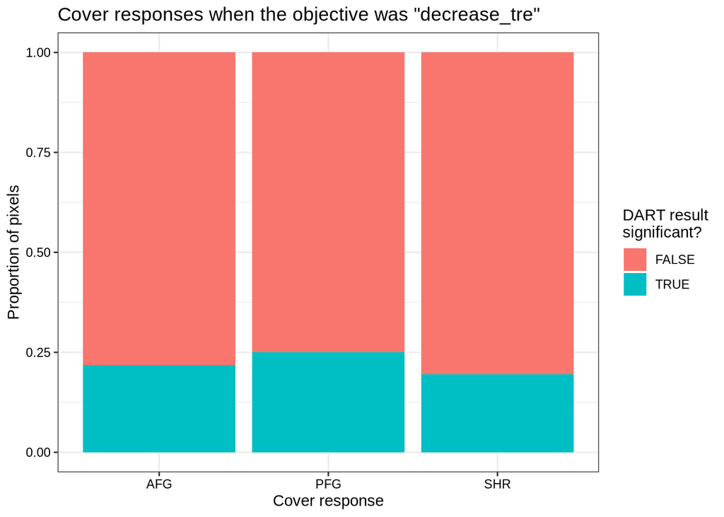

**Table and figure.** X axis of the figure: cover response (`'fun_group'`) - the non-target responses AFG, SHR and PFG, in pixels where `decrease_tre` was one of the assigned objectives. Y axis: proportion of that response’s pixels, with each bar filled to 1. Fill: whether the DART result was significant (`TRUE`/`FALSE`), so the bar reads as the significant share of that response. No facets. The figure shows only *whether* an effect was detected; the direction split is in the table above it, not on the figure.

As above, for pixels where increasing perennial forb and grass cover was an objective, looking at the AFG response only.

| Cover Response | Total Pixels | % Significant | % Significant Positive | % Significant Negative |
| --- | --- | --- | --- | --- |
| AFG | 605328 | 24.87 | 22.6 | 2.27 |

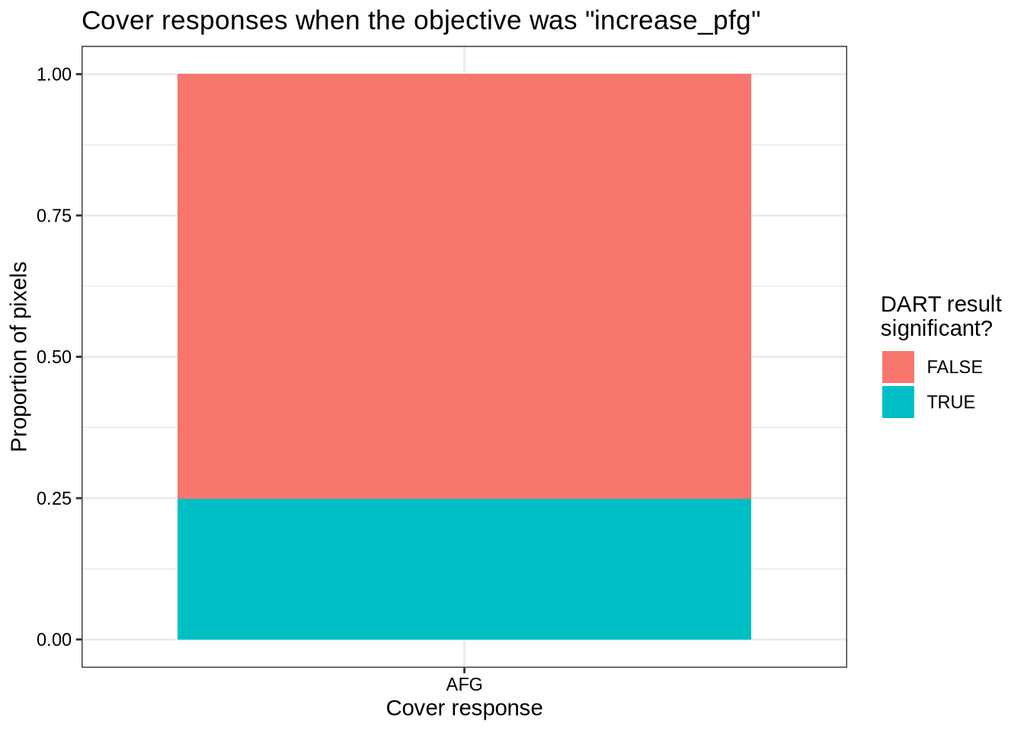

**Table and figure.** As above, for `increase_pfg` and the single non-target response AFG. X axis: cover response (one level, AFG). Y axis: proportion of AFG pixels, filled to 1. Fill: whether the DART result was significant. No facets. With only one cover response on the axis the figure adds nothing to the table; it is drawn for consistency with the other two checks.

As above, for pixels where decreasing shrub cover was an objective, looking at the AFG, PFG and TRE responses.

| Cover Response | Total Pixels | % Significant | % Significant Positive | % Significant Negative |
| --- | --- | --- | --- | --- |
| AFG | 187593 | 17.05 | 15.49 | 1.56 |
| PFG | 186172 | 16.84 | 12.15 | 4.69 |
| TRE | 186773 | 17.97 | 4.83 | 13.14 |

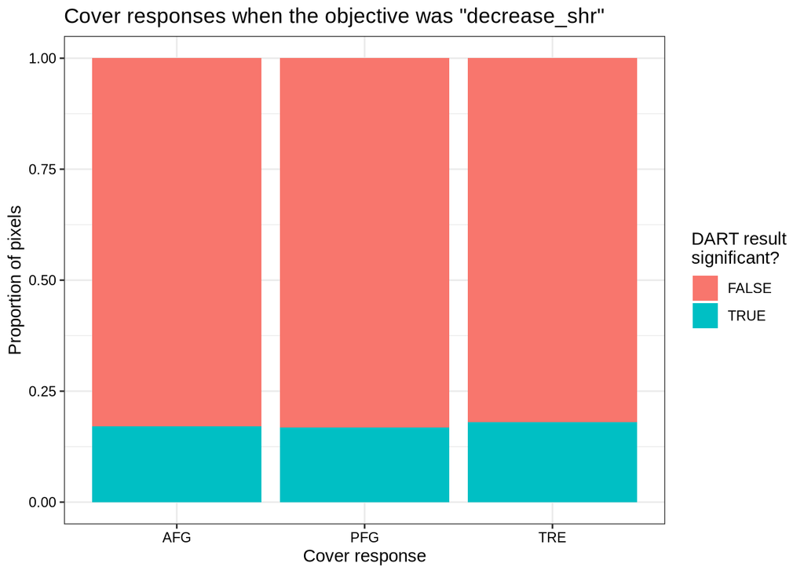

**Table and figure.** As above, for `decrease_shr` and the non-target responses AFG, PFG and TRE. X axis: cover response. Y axis: proportion of that response’s pixels, filled to 1. Fill: whether the DART result was significant. No facets.

## Compiled results across objectives

Each table below gathers the per-objective tables from the sections above into one table. All of them are built on the post-filter data held in `summaries_mod`, not on the raw split in `summaries`.

#### Sample-size filtering applied

Sample-size filtering per objective x cover response, one row each, reading left to right in the order the three filters are applied. (1) Sparse cells: the minimum-pixel threshold that combination was given and how many treatment x ecoregion combinations fell below it. (2) Depopulated levels: how many whole treatment or ecoregion levels were then left below that same threshold and removed - 0 everywhere if `drop_depopulated` is FALSE, which it is not in this run. (3) Late-year truncation: the minimum per-year count required, the first year that fell below it, and how many years were dropped from there to the end of the record; a blank means no year fell below the threshold and the series was not truncated. The metric counted per year is “significant” pixels (see the setup chunk) - on total pixels a small threshold truncates nothing on this data, so the choice of metric matters more than the number. “% Pixels Lost” is the combined cost of all three filters, not of any one. The last two columns count levels ABSENT from the post-filter data for any reason, which includes levels that only ever appeared in sparse cells and so is not the same quantity as the depopulated counts. Thresholds differ by objective here, so every compiled table below is comparing unequally filtered samples and should be read with this table alongside it.

| Objective | Cover | Min. Pixels per Tx x Ecoregion | # Combinations Excluded | # Tx Depopulated | # Eco Depopulated | Min. Significant Pixels per Year | Truncated From Year | # Years Dropped | % Pixels Lost (All Filters) | # Treatments Absent | # Ecoregions Absent |
| --- | --- | --- | --- | --- | --- | --- | --- | --- | --- | --- | --- |
| decrease_afg | AFG | 300 | 20 | 0 | 0 | 10 | 27 | 2 | 2.53 | 3 | 4 |
| decrease_shr | SHR | 300 | 8 | 0 | 0 | 10 | 33 | 1 | 0.50 | 1 | 2 |
| decrease_tre | TRE | 10 | 0 | 0 | 0 | 10 |  | 0 | 0.00 | 0 | 0 |
| increase_pfg | PFG | 300 | 27 | 0 | 0 | 10 |  | 0 | 0.48 | 1 | 6 |
| increase_shr | SHR | 300 | 27 | 0 | 0 | 10 |  | 0 | 1.20 | 1 | 8 |

#### Overall significance rate

Overall significance rate per objective x cover response, split by the raw sign of the effect. Percentages are of all pixels in that objective’s post-filter analysis set, so the two directional columns sum to the overall column up to rounding.

| Objective | Cover | Total Pixels | % Significant | % Significant Positive | % Significant Negative |
| --- | --- | --- | --- | --- | --- |
| decrease_afg | AFG | 84175 | 28.2 | 22.7 | 5.4 |
| decrease_shr | SHR | 186596 | 15.0 | 4.7 | 10.3 |
| decrease_tre | TRE | 556499 | 30.2 | 4.6 | 25.6 |
| increase_pfg | PFG | 605946 | 24.6 | 20.7 | 3.8 |
| increase_shr | SHR | 285880 | 23.5 | 14.9 | 8.6 |

#### Per-polygon significance

To calculate per-polygon SD/SE around the overall percentages above we collapse to one % significant per polygon, then take the mean/SD/SE of that per-polygon rate, giving a sense of how variable the overall significance rate is across polygons. This is different than overall significance because the data is being averaged twice - once at the polygon level then again at the objective level. One row per (objective x cover) response:

| Objective | Cover | N Polygons | Mean % Sig. | SD | SE | Mean % Sig. Positive | SD | SE | Mean % Sig. Negative | SD | SE |
| --- | --- | --- | --- | --- | --- | --- | --- | --- | --- | --- | --- |
| decrease_afg | AFG | 104 | 37.60 | 27.17 | 2.66 | 33.75 | 28.19 | 2.76 | 3.85 | 9.52 | 0.93 |
| decrease_shr | SHR | 61 | 25.87 | 22.26 | 2.85 | 5.35 | 12.69 | 1.63 | 20.52 | 21.90 | 2.80 |
| decrease_tre | TRE | 453 | 42.78 | 30.20 | 1.42 | 3.70 | 6.48 | 0.30 | 39.08 | 32.76 | 1.54 |
| increase_pfg | PFG | 539 | 31.00 | 28.05 | 1.21 | 28.02 | 29.21 | 1.26 | 2.98 | 5.82 | 0.25 |
| increase_shr | SHR | 386 | 28.45 | 24.74 | 1.26 | 17.00 | 22.68 | 1.15 | 11.45 | 19.66 | 1.00 |

All three metrics are drawn on one figure below (`metric = 'all'`), dodged within each objective: the overall per-polygon rate alongside its significant-positive and significant-negative components. Since the overall rate is the sum of the two directional rates, having them on the same axis shows directly which direction is responsible for a given objective’s overall significance rate.

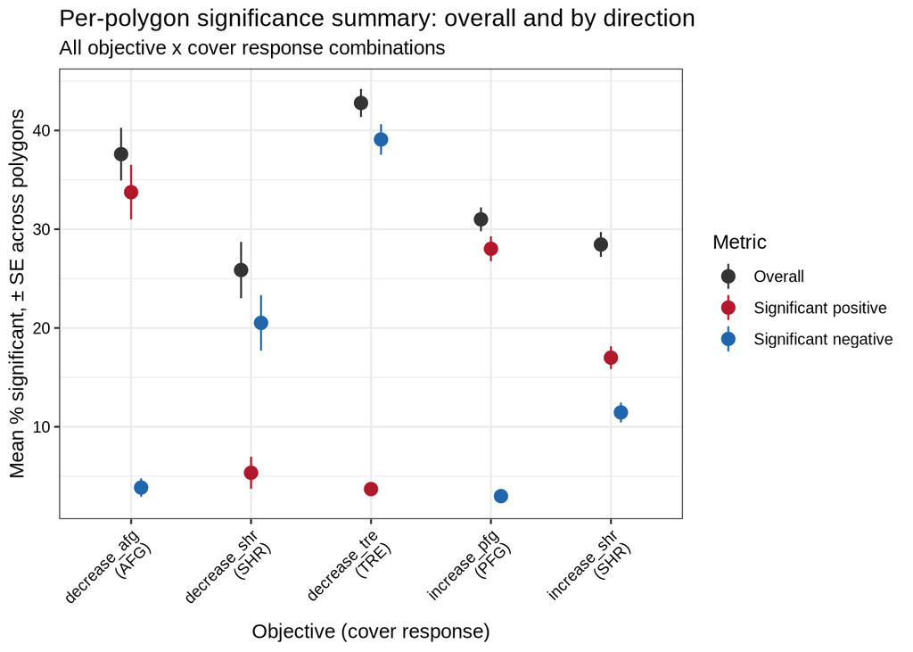

**Figure.** X axis: objective (with its cover response underneath), one position per row of the per-polygon summary table above. Y axis: the mean, across polygons, of that polygon’s percentage of significant pixels, with the vertical range showing ± 1 SE of that mean (the SE columns of the table above). Colour: which of the three per-polygon rates is drawn - grey for the overall rate, red for the significant-positive component and blue for the significant-negative component, dodged side by side within each objective so the two directions can be read against the total they sum to. The dodge offset is deliberately narrow so that each objective’s three points stay visibly clustered on its own axis tick now that every objective is on one figure. Colours for the two directions are the same ones used in the direction figures in each objective’s section. No facets.

#### Effect size and timing

Year of largest mean DART effect, one row per objective x cover response x direction. A censored peak lands on the last year observed for that direction, so the effect may still have been growing past the end of the record.

| Objective (Cover) | Direction | Peak Year | Mean Effect at Peak | SE | Significant Pixels at Peak | Last Year Observed | Peak Censored? |
| --- | --- | --- | --- | --- | --- | --- | --- |
| decrease_afg_AFG | negative | 18 | -43.2565 | 1.7902 | 132 | 26 | FALSE |
| decrease_afg_AFG | positive | 25 | 28.7774 | 3.5268 | 10 | 26 | FALSE |
| decrease_shr_SHR | negative | 1 | -21.3814 | 0.2574 | 2455 | 32 | FALSE |
| decrease_shr_SHR | positive | 27 | 14.1992 | NA | 1 | 32 | FALSE |
| decrease_tre_TRE | negative | 29 | -26.6402 | 1.0229 | 100 | 33 | FALSE |
| decrease_tre_TRE | positive | 31 | 14.2400 | 1.2612 | 27 | 33 | FALSE |
| increase_pfg_PFG | negative | 21 | -10.5936 | 0.1468 | 733 | 33 | FALSE |
| increase_pfg_PFG | positive | 33 | 23.4308 | 2.3622 | 17 | 33 | TRUE |
| increase_shr_SHR | negative | 2 | -11.8737 | 0.1131 | 2907 | 30 | FALSE |
| increase_shr_SHR | positive | 20 | 14.0138 | 0.3377 | 378 | 30 | FALSE |

Significance rates binned by years since treatment (1-5, 6-10, 11-15, 16+), one row per objective x cover response x bin.

| Objective | Cover | Year Bin | Total Pixels | Mean % Significant | Mean % Significant Positive | Mean % Significant Negative |
| --- | --- | --- | --- | --- | --- | --- |
| decrease_afg | AFG | 1-5 | 30549 | 37.19 | 31.14 | 6.05 |
| decrease_afg | AFG | 6-10 | 24418 | 29.20 | 23.66 | 5.53 |
| decrease_afg | AFG | 11-15 | 16895 | 20.66 | 15.79 | 4.88 |
| decrease_afg | AFG | 16+ | 12313 | 14.03 | 9.64 | 4.39 |
| decrease_shr | SHR | 1-5 | 45846 | 23.11 | 5.79 | 17.32 |
| decrease_shr | SHR | 6-10 | 43563 | 14.98 | 5.57 | 9.41 |
| decrease_shr | SHR | 11-15 | 40274 | 13.25 | 4.58 | 8.67 |
| decrease_shr | SHR | 16+ | 56913 | 9.83 | 3.30 | 6.54 |
| decrease_tre | TRE | 1-5 | 189705 | 37.55 | 2.82 | 34.73 |
| decrease_tre | TRE | 6-10 | 156175 | 31.74 | 4.43 | 27.31 |
| decrease_tre | TRE | 11-15 | 113531 | 25.46 | 5.71 | 19.76 |
| decrease_tre | TRE | 16+ | 97088 | 18.76 | 6.88 | 11.89 |
| increase_pfg | PFG | 1-5 | 183780 | 31.35 | 27.84 | 3.52 |
| increase_pfg | PFG | 6-10 | 157858 | 26.57 | 23.96 | 2.62 |
| increase_pfg | PFG | 11-15 | 124093 | 20.55 | 17.25 | 3.31 |
| increase_pfg | PFG | 16+ | 140215 | 16.95 | 10.94 | 6.01 |
| increase_shr | SHR | 1-5 | 105532 | 29.18 | 17.98 | 11.20 |
| increase_shr | SHR | 6-10 | 80672 | 22.64 | 15.06 | 7.59 |
| increase_shr | SHR | 11-15 | 50252 | 18.44 | 12.08 | 6.36 |
| increase_shr | SHR | 16+ | 49424 | 17.74 | 11.01 | 6.73 |

The two tables above answer the two different questions this report keeps separate throughout the time-since-treatment work, and each gets its own figure below: how **large** the significant effects were and when they peaked (`peak_effect_all`, first figure), and how **often** a significant effect occurred within each year bin (`sig_by_bin_all`, second figure). They can disagree - a bin can carry a high significance rate made up of small effects, or a small number of large ones - so they are drawn as two figures rather than combined into one.

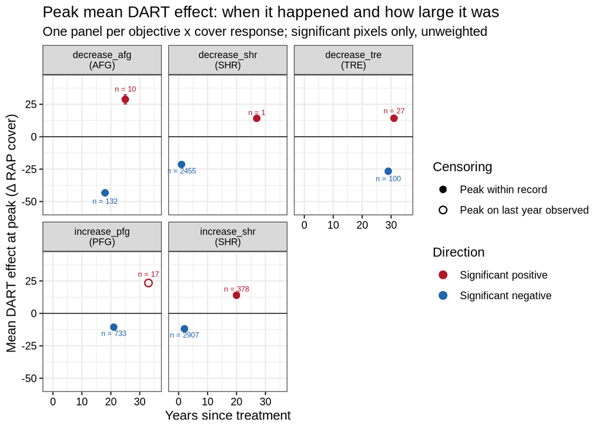

**Figure.** X axis: years since treatment at which the mean DART effect over significant pixels was largest in magnitude - the `Peak Year` column of the first table above. Y axis: the mean DART effect (Δ RAP cover) at that peak year, with the vertical bar showing ± 1 SE of that mean (the `SE` column); the horizontal line marks zero, which the two directions sit either side of by construction. Colour: direction of the effect (red = significant positive, blue = significant negative), the same colours used in every direction figure in this report, with the two directions never averaged together. Shape: whether the peak is censored - a filled circle is a peak falling inside the record, a hollow circle a peak landing on the last year observed for that direction, where the effect may still have been growing past the end of the record. Facets: objective x cover response, one panel each, on a shared y axis so panels can be compared against each other. The `n =` label on each point is the number of significant pixels behind that peak mean, which for late peaks is frequently in the tens - a peak backed by ten pixels sits on the same axis as one backed by thousands, and the axis alone does not say which is which.

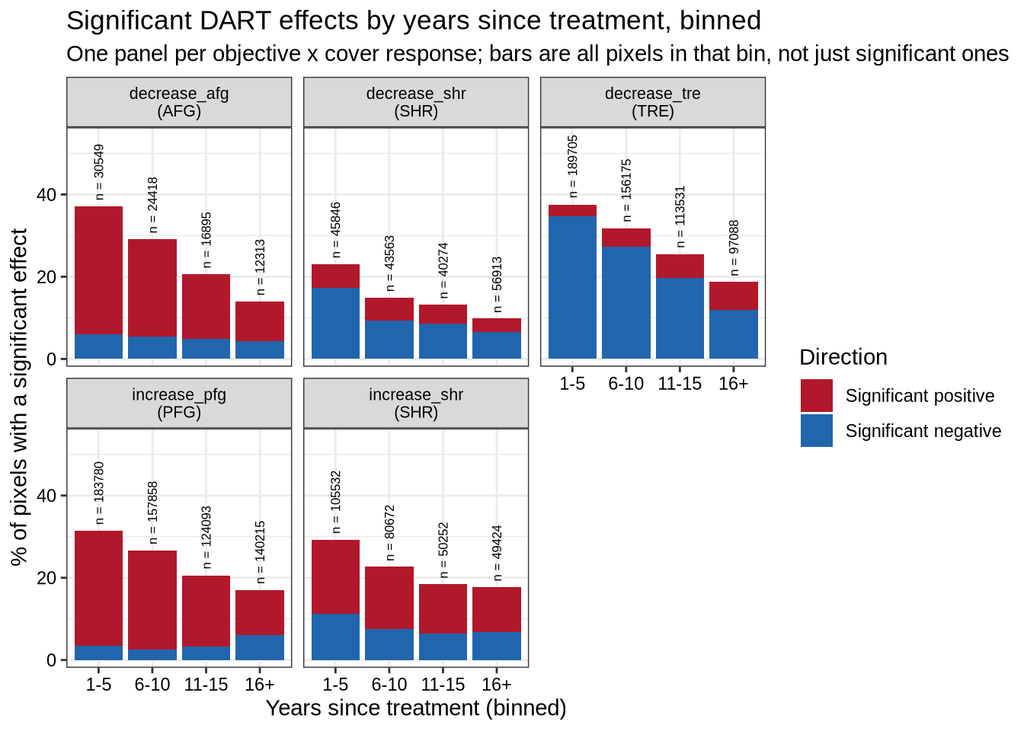

**Figure.** X axis: years since treatment, binned as 1-5, 6-10, 11-15 and 16+ - the `Year Bin` column of the second table above. Y axis: the percentage of that bin’s pixels with a significant DART effect, so the full height of a bar is the bin’s overall rate and the denominator is every pixel observed in that bin, significant or not. Fill: the direction of the significant effect, splitting each bar into a blue *significant negative* component against the axis and a red *significant positive* component above it; the two sum to the bar’s full height. Unlike the per-year stacked figure in each objective’s section, the stacking order is the same in every panel rather than putting the intended direction against the axis, because intent differs between panels - negative is intended for a `decrease_*` objective and positive for an `increase_*` one - so the fill colours carry the raw sign only and the objective name in the panel strip says which of them was wanted. Facets: objective x cover response, one panel each, on a shared y axis. The rotated `n =` label above each bar is that bin’s total pixel count, i.e. the denominator of the percentage rather than the count of significant pixels.

#### Objective overlap

Objective co-occurrence, one row per objective x co-occurring objective, with a “none” row per objective for the pixels that carried no other objective. Percentages are of the pixels used in that objective’s own (post-filter) analysis, not of the full combined dataset.

| Objective | Cover | Co-occurring Objective | Pixel Count | % of Total Pixels |
| --- | --- | --- | --- | --- |
| decrease_afg | AFG | none | 4781 | 5.68 |
| decrease_afg | AFG | increase_pfg | 66639 | 79.17 |
| decrease_afg | AFG | increase_shr | 45214 | 53.71 |
| decrease_afg | AFG | decrease_tre | 10900 | 12.95 |
| decrease_afg | AFG | decrease_shr | 4101 | 4.87 |
| decrease_shr | SHR | none | 8560 | 4.59 |
| decrease_shr | SHR | increase_pfg | 158996 | 85.21 |
| decrease_shr | SHR | decrease_tre | 152872 | 81.93 |
| decrease_shr | SHR | decrease_afg | 4101 | 2.20 |
| decrease_shr | SHR | null_afg | 2684 | 1.44 |
| decrease_shr | SHR | increase_afg | 501 | 0.27 |
| decrease_tre | TRE | none | 212111 | 38.12 |
| decrease_tre | TRE | increase_pfg | 298600 | 53.66 |
| decrease_tre | TRE | decrease_shr | 153000 | 27.49 |
| decrease_tre | TRE | increase_shr | 135253 | 24.30 |
| decrease_tre | TRE | null_afg | 23897 | 4.29 |
| decrease_tre | TRE | decrease_afg | 12462 | 2.24 |
| decrease_tre | TRE | increase_afg | 12219 | 2.20 |
| increase_pfg | PFG | none | 114791 | 18.94 |
| increase_pfg | PFG | decrease_tre | 296185 | 48.88 |
| increase_pfg | PFG | increase_shr | 254403 | 41.98 |
| increase_pfg | PFG | decrease_shr | 157896 | 26.06 |
| increase_pfg | PFG | decrease_afg | 69232 | 11.43 |
| increase_pfg | PFG | null_afg | 21643 | 3.57 |
| increase_pfg | PFG | increase_afg | 18667 | 3.08 |
| increase_pfg | PFG | increase_tre | 2997 | 0.49 |
| increase_shr | SHR | none | 2525 | 0.88 |
| increase_shr | SHR | increase_pfg | 254531 | 89.03 |
| increase_shr | SHR | decrease_tre | 134904 | 47.19 |
| increase_shr | SHR | decrease_afg | 47256 | 16.53 |
| increase_shr | SHR | increase_afg | 17087 | 5.98 |
| increase_shr | SHR | null_afg | 14012 | 4.90 |
| increase_shr | SHR | increase_tre | 2317 | 0.81 |

#### Summary table

One row per objective x cover response x treatment x ecoregion, stacked across every objective in the report. **This table is the working draft of the reporting deliverable, and the bulleted definitions below are what define its columns.**

Every row is built from that objective’s **post-filter** data, and the thresholds differ by objective, so rows from different objectives describe unequally filtered samples - read the filtering log above before comparing them. Column by column, with the denominator named wherever there is more than one it could be:

- **`n_time_objective`** (*# Times This Was Objective*) - the number of polygons belonging to this objective, counted on the **unfiltered** split, so it is a scope figure rather than a post-filter one. Constant across every row of an objective.
- **`pct_time_objective`** (*% of Time This Was Objective*) - the same count over the polygon total summed across all five elements of `summaries`. A polygon is counted once per element it appears in, so the denominator counts objective-polygon pairs, not distinct polygons; the column does sum to 100 across the five objectives.
- **`objective`**, **`cover`** (*Cover Response*), **`tx_coarse`** (*Treatment Method*), **`us_l4name`** (*Ecoregion*) - the four grouping keys, one row per combination. `cover` is the differenced RAP cover response (the `fun_group` column, renamed); `tx_coarse` is the coarse treatment string, so a polygon treated several ways carries a compound value such as `seeding;vegetation removal` rather than appearing once per component.
- **`n_time_treatment`** (*# Times This Was Treatment*) - distinct polygons within this objective’s post-filter data that received this treatment, pooled over ecoregions. Constant across the ecoregion rows of one objective x treatment pair.
- **`pct_time_treatment`** (*% of Time This Was Treatment*) - `n_time_treatment` over `n_time_objective`. This is a post-filter numerator over an unfiltered denominator, and a polygon treated more than one way is counted under each of its treatments, so the column is not expected to sum to 100 within an objective.
- **`grp_n_pix`** (*Total Pixels*) - pixels in this cell after all three sample-size filters. This is the denominator behind the per-pixel rates quoted elsewhere in the report.
- **`grp_n_poly`** (*Number Polygons*) - distinct polygons contributing those pixels.
- **`grp_n_sig`** (*# Significant Pixels*) - pixels whose DART confidence interval excludes zero, in either direction.
- **`grp_n_sig_int`** / **`grp_n_sig_uni`** (*# Significant Pixels (Intended)* / *(Unintended)*) - that count split by whether the raw sign matched this objective’s goal, via `get_intended_sign()`. They sum to `grp_n_sig`.
- **`grp_perc_int`** / **`grp_perc_uni`** (*% Significant Pixels (Intended)* / *(Unintended)*) - **percentages of `grp_n_sig`, not of `grp_n_pix`.** They sum to 100 up to rounding. This is the one column pair whose rendered label can mislead: it is the composition of the significant pixels, not the share of the cell that was significant. Two consequences worth knowing. A cell with no significant pixels divides zero by zero, giving an undefined percentage; those cells render **blank**, and `# Significant Pixels` reads 0 alongside them. There are two such rows in the current draft, both `decrease_tre` cells, of 75 and 50 pixels. And the share-of-all-pixels version (`grp_perc_sig`, significant over total) is computed inside `reduce_s0()` but deliberately not carried into this table, so a reader who wants “how much of this cell responded” has to divide `grp_n_sig` by `grp_n_pix` themselves.

| # Times This Was Objective | % of Time This Was Objective | Objective | Cover Response | Treatment Method | # Times This Was Treatment | % of Time This Was Treatment | Ecoregion | Total Pixels | Number Polygons | # Significant Pixels | # Significant Pixels (Intended) | # Significant Pixels (Unintended) | % Significant Pixels (Intended) | % Significant Pixels (Unintended) |
| --- | --- | --- | --- | --- | --- | --- | --- | --- | --- | --- | --- | --- | --- | --- |
| 126 | 7.68 | decrease_afg | AFG | seeding | 32 | 25.40 | Dissected High Lava Plateau | 2448 | 1 | 695 | 4 | 691 | 0.58 | 99.42 |
| 126 | 7.68 | decrease_afg | AFG | seeding | 32 | 25.40 | Escarpments | 1564 | 3 | 73 | 40 | 33 | 54.79 | 45.21 |
| 126 | 7.68 | decrease_afg | AFG | seeding | 32 | 25.40 | Foothill Shrublands and Low Mountains | 900 | 1 | 260 | 21 | 239 | 8.08 | 91.92 |
| 126 | 7.68 | decrease_afg | AFG | seeding | 32 | 25.40 | Monticello-Cortez Uplands | 666 | 1 | 460 | 2 | 458 | 0.43 | 99.57 |
| 126 | 7.68 | decrease_afg | AFG | seeding | 32 | 25.40 | Northern Uinta Basin Slopes | 1501 | 1 | 804 | 40 | 764 | 4.98 | 95.02 |
| 126 | 7.68 | decrease_afg | AFG | seeding | 32 | 25.40 | Sagebrush Basins and Slopes | 6753 | 14 | 1184 | 98 | 1086 | 8.28 | 91.72 |
| 126 | 7.68 | decrease_afg | AFG | seeding | 32 | 25.40 | Semiarid Benchlands and Canyonlands | 5576 | 4 | 1782 | 131 | 1651 | 7.35 | 92.65 |
| 126 | 7.68 | decrease_afg | AFG | seeding | 32 | 25.40 | Semiarid Hills and Low Mountains | 854 | 1 | 484 | 64 | 420 | 13.22 | 86.78 |
| 126 | 7.68 | decrease_afg | AFG | seeding | 32 | 25.40 | Woodland- and Shrub-Covered Low Mountains | 7383 | 6 | 2230 | 118 | 2112 | 5.29 | 94.71 |
| 126 | 7.68 | decrease_afg | AFG | seeding;soil disturbance | 21 | 16.67 | Sagebrush Basins and Slopes | 6533 | 4 | 902 | 220 | 682 | 24.39 | 75.61 |
| 126 | 7.68 | decrease_afg | AFG | seeding;soil disturbance | 21 | 16.67 | Semiarid Benchlands and Canyonlands | 936 | 2 | 289 | 7 | 282 | 2.42 | 97.58 |
| 126 | 7.68 | decrease_afg | AFG | seeding;soil disturbance | 21 | 16.67 | Semiarid Foothills | 1677 | 5 | 898 | 11 | 887 | 1.22 | 98.78 |
| 126 | 7.68 | decrease_afg | AFG | seeding;soil disturbance | 21 | 16.67 | Shadscale-Dominated Saline Basins | 11086 | 4 | 1153 | 756 | 397 | 65.57 | 34.43 |
| 126 | 7.68 | decrease_afg | AFG | seeding;soil disturbance | 21 | 16.67 | Woodland- and Shrub-Covered Low Mountains | 2120 | 6 | 1722 | 3 | 1719 | 0.17 | 99.83 |
| 126 | 7.68 | decrease_afg | AFG | seeding;soil disturbance;vegetation removal | 16 | 12.70 | Mountain Valleys | 505 | 2 | 42 | 32 | 10 | 76.19 | 23.81 |
| 126 | 7.68 | decrease_afg | AFG | seeding;soil disturbance;vegetation removal | 16 | 12.70 | Rolling Sagebrush Steppe | 874 | 1 | 78 | 6 | 72 | 7.69 | 92.31 |
| 126 | 7.68 | decrease_afg | AFG | seeding;soil disturbance;vegetation removal | 16 | 12.70 | Sagebrush Basins and Slopes | 1241 | 3 | 396 | 28 | 368 | 7.07 | 92.93 |
| 126 | 7.68 | decrease_afg | AFG | seeding;soil disturbance;vegetation removal | 16 | 12.70 | Semiarid Benchlands and Canyonlands | 1104 | 3 | 177 | 46 | 131 | 25.99 | 74.01 |
| 126 | 7.68 | decrease_afg | AFG | seeding;soil disturbance;vegetation removal | 16 | 12.70 | Semiarid Foothills | 616 | 1 | 414 | 0 | 414 | 0.00 | 100.00 |
| 126 | 7.68 | decrease_afg | AFG | seeding;soil disturbance;vegetation removal | 16 | 12.70 | Shadscale-Dominated Saline Basins | 3750 | 1 | 176 | 50 | 126 | 28.41 | 71.59 |
| 126 | 7.68 | decrease_afg | AFG | seeding;soil disturbance;vegetation removal | 16 | 12.70 | Uinta Basin Floor | 1008 | 1 | 337 | 260 | 77 | 77.15 | 22.85 |
| 126 | 7.68 | decrease_afg | AFG | seeding;soil disturbance;vegetation removal | 16 | 12.70 | Woodland- and Shrub-Covered Low Mountains | 2147 | 4 | 1150 | 102 | 1048 | 8.87 | 91.13 |
| 126 | 7.68 | decrease_afg | AFG | seeding;vegetation removal | 18 | 14.29 | Dissected High Lava Plateau | 380 | 1 | 120 | 22 | 98 | 18.33 | 81.67 |
| 126 | 7.68 | decrease_afg | AFG | seeding;vegetation removal | 18 | 14.29 | Escarpments | 1373 | 3 | 668 | 57 | 611 | 8.53 | 91.47 |
| 126 | 7.68 | decrease_afg | AFG | seeding;vegetation removal | 18 | 14.29 | Sagebrush Basins and Slopes | 711 | 4 | 300 | 60 | 240 | 20.00 | 80.00 |
| 126 | 7.68 | decrease_afg | AFG | seeding;vegetation removal | 18 | 14.29 | Semiarid Foothills | 469 | 2 | 91 | 7 | 84 | 7.69 | 92.31 |
| 126 | 7.68 | decrease_afg | AFG | seeding;vegetation removal | 18 | 14.29 | Semiarid Hills and Low Mountains | 350 | 1 | 300 | 0 | 300 | 0.00 | 100.00 |
| 126 | 7.68 | decrease_afg | AFG | seeding;vegetation removal | 18 | 14.29 | Shadscale-Dominated Saline Basins | 384 | 1 | 61 | 58 | 3 | 95.08 | 4.92 |
| 126 | 7.68 | decrease_afg | AFG | seeding;vegetation removal | 18 | 14.29 | Woodland- and Shrub-Covered Low Mountains | 2419 | 6 | 1511 | 84 | 1427 | 5.56 | 94.44 |
| 126 | 7.68 | decrease_afg | AFG | soil disturbance;vegetation removal | 2 | 1.59 | Semiarid Benchlands and Canyonlands | 455 | 1 | 271 | 2 | 269 | 0.74 | 99.26 |

[output cut: 254 more lines]

#### Tables written to .csv

Compiled tables written to `../analysis_inputs/results`. A table that came back empty is skipped rather than written as an empty file.

| Table | File | Rows | Columns |
| --- | --- | --- | --- |
| filtering_log | 2_DART_results_filtering_log.csv | 5 | 12 |
| txeco_pixel_counts_postfilter | 2_DART_results_txeco_pixel_counts_postfilter.csv | 284 | 5 |
| overall_significance | 2_DART_results_overall_significance.csv | 5 | 6 |
| intended_effect | 2_DART_results_intended_effect.csv | 5 | 6 |
| polygon_significance | 2_DART_results_polygon_significance.csv | 5 | 12 |
| peak_effect_year | 2_DART_results_peak_effect_year.csv | 10 | 8 |
| year_bin_significance | 2_DART_results_year_bin_significance.csv | 20 | 7 |
| objective_overlap | 2_DART_results_objective_overlap.csv | 33 | 5 |
| summary_table | 2_DART_results_summary_table.csv | 284 | 15 |

## Summary results

### Interpretation

This section is plain markdown, written by hand, and it sits at the **end** of the report rather than ahead of the results. Everything above the horizontal rule is generated - the cross-objective checks and the compiled tables - and nothing here is, so text written here is not overwritten when the report is re-rendered. It reads better last: the interpretations refer to tables and figures by name, and a reader who has just passed those tables does not have to scroll forward to find what is being described.

Only **cross-objective** readings belong here. Each objective’s own interpretation is written directly beneath that objective’s tables and figures in `2_sample_size_checks.Rmd`, which is the document that shows the evidence it refers to.

Write in whatever structure ends up being useful - the headings below are a starting point, not a fixed schema, and any of them can be deleted or renamed.

#### Across all objectives

To be written.

- CLAUDE: Ranked by the share of pixels that moved significantly in the intended direction, the objectives run **decrease_tre** 25.6%, **increase_pfg** 20.7%, **increase_shr** 14.9%, **decrease_shr** 10.3%, **decrease_afg** 5.4%. That is better than a fourfold spread across objectives measured the same way on the same imagery, so “did treatment work” has no single answer here - it is a question about which objective was being pursued, and the answer should always be given per objective.
- CLAUDE: decrease_afg is the only objective whose unintended rate exceeds its intended one (22.7% against 5.4%). It is also among the least independent samples in the report - see the overlap caveat below - so the most defensible reading is that treatments aimed at reducing annual grass were usually doing something else as well, rather than that annual-grass reduction actively backfires.
- CLAUDE: Within each objective the treatment ordering points the same way, and it is the most actionable pattern in the report. Every objective’s top treatment is seeding, mechanical vegetation removal or soil disturbance, alone or combined (decrease_afg: vegetation removal, 14.1%; decrease_shr: seeding, 24.1%; decrease_tre: seeding;vegetation removal, 51.4%; increase_pfg: seeding;vegetation removal, 39.9%; increase_shr: soil disturbance, 32.2%), while `prescribed burn` on its own ranks 10 of 11 (8.7%) for decrease_shr, 11 of 13 (11.6%) for decrease_tre, 10 of 12 (9.7%) for increase_pfg, 11 of 12 (7.4%) for increase_shr. Each ranking is computed inside one objective, so the unequal thresholds do not affect it.
- CLAUDE: The corollary is worth stating for the report’s audience: the evidence here supports *how* a treatment was carried out mattering more than *which* cover type it targeted. The best-performing objective at 25.6% intended and the worst at 5.4% both contain treatments spanning most of the observed range.

#### Time since treatment

To be written. The per-year and binned significance results, the mean-effect peaks, and the censoring flags all speak to this.

- CLAUDE: Detectable treatment effects are a property of the first decade after treatment, and this is the clearest finding in the report. The overall significance rate falls in every successive year bin in 5 of 5 objectives and the intended rate does the same in 5 of 5; by the 16+ bin the overall rate is down to 38-61% of its years 1-5 value. Any percentage quoted without a year window is an average over a changing regime.
- CLAUDE: What the *unintended* rate does over that span differs by objective, and this is where the interpretation has to be careful rather than uniform. It ends higher than it started for decrease_tre and increase_pfg, so for those the intended-to-unintended ratio collapses (decrease_tre 12.3:1 to 1.7:1; increase_pfg 7.9:1 to 1.8:1) - the intended signal decays *and* opposite-sign pixels accumulate. For the rest the unintended rate decays too, so the balance between them is roughly preserved or, for `decrease_afg`, becomes less unfavourable. Stating the pattern as “effects regress over time” is right for the first group and wrong for the second.
- CLAUDE: Peak-magnitude timing is the weakest evidence in the document and should not be asked to carry an argument. 4 of the 10 rows in the peak table rest on fewer than 50 significant pixels, 1 is censored at the last observed year, and because the peak is computed over significant pixels only, a late year with a handful of surviving significant pixels can outrank a well-populated early one. The year-bin table above and the per-polygon peak-significance years in `2_sample_size_checks.Rmd` - where every treatment’s mean peak falls inside the first decade - are the better basis for a timing claim.
- CLAUDE: On the censoring note carried over below: only 1 of the compiled peaks is actually flagged (increase_pfg_PFG, positive, year 33), so censoring is not what limits the timing story at present - the thin-pixel problem is, and it is not flagged anywhere in the tables.

Carried over from the single-objective version of this report, where it sat with the per-polygon peak/trough tables: a polygon’s peak (or trough) year is flagged as censored when it falls on the last year that polygon was observed, so in those cases we can’t rule out that significance was still rising (or falling) beyond the end of the available time series. “There are implications here for stable-state-change discussion.”

#### Caveats and open questions

To be written. Two caveats apply throughout and are worth restating wherever a number is quoted: the objective groupings are not a partition (a pixel counts toward an objective if it fell in any part of that objective, so multi-objective treatments appear in several groupings and parts of the dataset are counted more than once), and an objective/response pairing is only included when the response cover type matches the objective’s target cover.

- CLAUDE: The not-a-partition caveat is quantitatively severe, not a formality. Only 1 of the 5 objectives keeps more than a fifth of its pixels to itself (decrease_tre, 38.1%), and the least independent is increase_shr at 0.9%. Per-objective results are therefore repeated readings of overlapping ground under different goals, and they cannot be added up or treated as independent replicates of “restoration treatment”.
- CLAUDE: The one comparison to avoid outright is reading `decrease_tre`’s covariate breakdowns against the other four at face value: its per-cell floor is 10 pixels against 300 for the others, so it retains treatment x ecoregion cells the other sections dropped. Combined filter cost still ranges only 0.00-2.53% of pixels, so the thresholds change which *levels* are present far more than how much data is in play.